# Code-Through Tutorial

## 1. Introduction

## Overview

In this tutorial, we will explore the basics of data visualization in R using the `ggplot2` package. Data visualization is a crucial aspect of data analysis, allowing us to understand patterns, trends, and insights effectively. `ggplot2` is a powerful and flexible package for creating static and interactive plots in R.

## Why Use `ggplot2`?

- Easy-to-use layered grammar of graphics
- Highly customizable
- Can handle large datasets efficiently
- Supports various types of plots

## 2. Setting Up the Environment

## Load the needed libraries

```r
# Load necessary libraries
library(ggplot2)
library(dplyr)
library(maps)
library(ggthemes)
library(kableExtra) # Added for better table rendering
```

## 3. Exploring a Dataset

## Overview

We will use the built-in `mtcars` dataset, which contains data on different car models, including miles per gallon (mpg), horsepower (hp), weight (wt), and other characteristics.

```r
# View first few rows of the dataset
head(mtcars)
```

```
##                    mpg cyl disp  hp drat    wt  qsec vs am gear carb
## Mazda RX4         21.0   6  160 110 3.90 2.620 16.46  0  1    4    4
## Mazda RX4 Wag     21.0   6  160 110 3.90 2.875 17.02  0  1    4    4
## Datsun 710        22.8   4  108  93 3.85 2.320 18.61  1  1    4    1
## Hornet 4 Drive    21.4   6  258 110 3.08 3.215 19.44  1  0    3    1
## Hornet Sportabout 18.7   8  360 175 3.15 3.440 17.02  0  0    3    2
## Valiant           18.1   6  225 105 2.76 3.460 20.22  1  0    3    1
```

## Summary Statistics

|  | mpg | cyl | disp | hp | drat | wt | qsec | vs | am | gear | carb |
| --- | --- | --- | --- | --- | --- | --- | --- | --- | --- | --- | --- |
|  | Min. :10.40 | Min. :4.000 | Min. : 71.1 | Min. : 52.0 | Min. :2.760 | Min. :1.513 | Min. :14.50 | Min. :0.0000 | Min. :0.0000 | Min. :3.000 | Min. :1.000 |
|  | 1st Qu.:15.43 | 1st Qu.:4.000 | 1st Qu.:120.8 | 1st Qu.: 96.5 | 1st Qu.:3.080 | 1st Qu.:2.581 | 1st Qu.:16.89 | 1st Qu.:0.0000 | 1st Qu.:0.0000 | 1st Qu.:3.000 | 1st Qu.:2.000 |
|  | Median :19.20 | Median :6.000 | Median :196.3 | Median :123.0 | Median :3.695 | Median :3.325 | Median :17.71 | Median :0.0000 | Median :0.0000 | Median :4.000 | Median :2.000 |
|  | Mean :20.09 | Mean :6.188 | Mean :230.7 | Mean :146.7 | Mean :3.597 | Mean :3.217 | Mean :17.85 | Mean :0.4375 | Mean :0.4062 | Mean :3.688 | Mean :2.812 |
|  | 3rd Qu.:22.80 | 3rd Qu.:8.000 | 3rd Qu.:326.0 | 3rd Qu.:180.0 | 3rd Qu.:3.920 | 3rd Qu.:3.610 | 3rd Qu.:18.90 | 3rd Qu.:1.0000 | 3rd Qu.:1.0000 | 3rd Qu.:4.000 | 3rd Qu.:4.000 |
|  | Max. :33.90 | Max. :8.000 | Max. :472.0 | Max. :335.0 | Max. :4.930 | Max. :5.424 | Max. :22.90 | Max. :1.0000 | Max. :1.0000 | Max. :5.000 | Max. :8.000 |

## 4. Data Visualization

## Scatter Plot: MPG vs Horsepower

A scatter plot is useful for visualizing relationships between two continuous variables. Here, we plot `mpg` against `hp`.

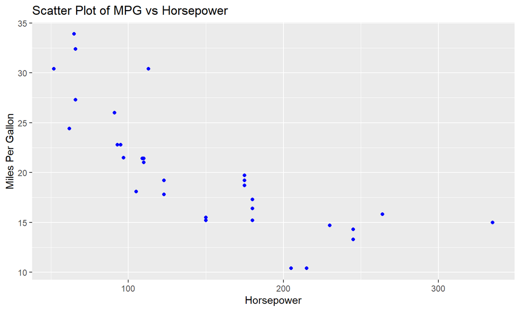

## Histogram: Distribution of MPG

A histogram helps visualize the distribution of a single numeric variable. Below, we create a histogram of `mpg`.

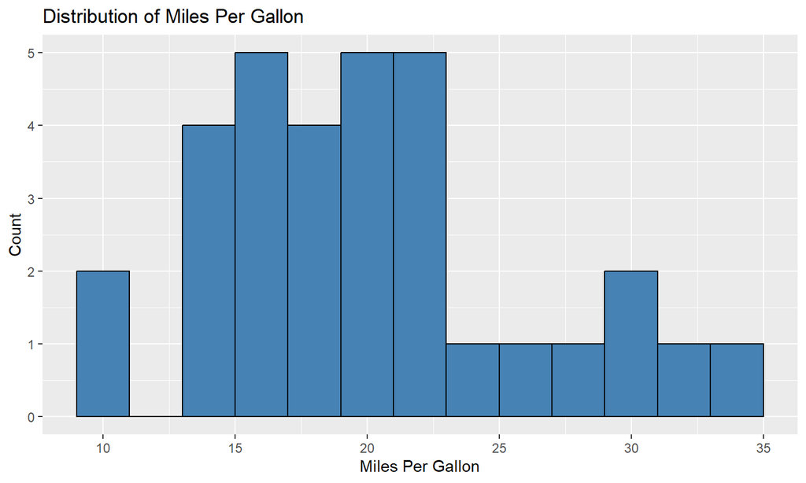

## 5. Map of Fuel Efficiency by State

## Introduction

A choropleth map visualizes data using color shading across geographical regions. Here, we create a state-level map of average miles per gallon (mpg) using synthetic data.

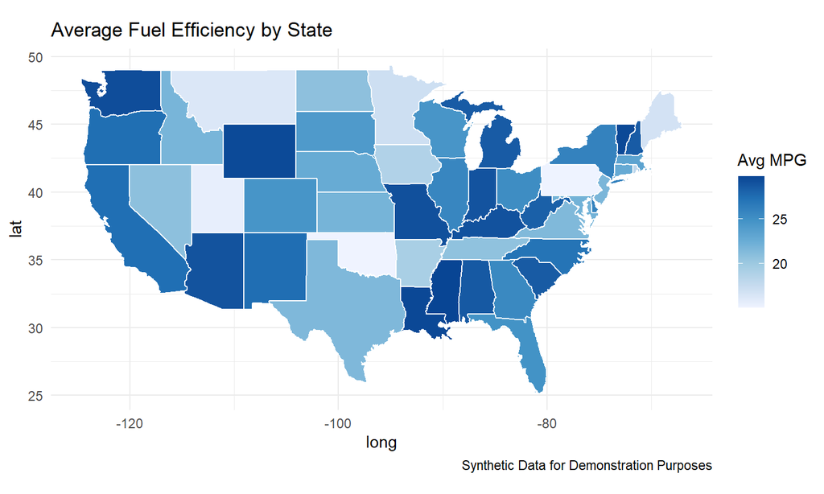

## 6. Conclusion

## Summary

- `ggplot2` is a powerful tool for data visualization in R.
- We explored scatter plots, histograms, and a choropleth map for fuel efficiency.
- Customization options allow us to create informative and visually appealing plots.

## Next Steps

- Explore additional `ggplot2` functionalities such as faceting and interactive plots.
- Use different datasets to practice visualization techniques.

This concludes our code-through tutorial on data visualization using `ggplot2`! 🎉